# Probability and Statistics

# Lab Assignment 1: Naive Bayes Classifier

## Work breakdown

- *Ievhenii Bevz* - **Data pre-processing, data visualization**, **conclusions**
- *Yuliia Vistak* - **Classifier implementation**
- *Together* - **Measurements of effectiveness of your classifier**

### Variant 2 - fake news

## Introduction

During the first three weeks, you learned a couple of essential notions and theorems, and one of the most important among them is the *Bayes theorem*.

One of its applications is **Naive Bayes classifier**, which is a probabilistic classifier whose aim is to determine which class some observation probably belongs to by using the Bayes formula:
$$\mathsf{P}(\mathrm{class}\mid
\mathrm{observation})=\frac{\mathsf{P}(\mathrm{observation}\mid\mathrm{class})\mathsf{P}(\mathrm{class})}{\mathsf{P}(\mathrm{observation})}$$

Under the strong independence assumption, one can calculate $\mathsf{P}(\mathrm{observation} \mid \mathrm{class})$ as
$$\mathsf{P}(\mathrm{observation}) =
\prod_{i=1}^{n} \mathsf{P}(\mathrm{feature}_i), \qquad
\mathsf{P}(\mathrm{observation} \mid \mathrm{class}) = \prod_{i=1}^{n}
\mathsf{P}(\mathrm{feature}_i \mid \mathrm{class}),$$
where $n$ is the total number of features describing a given observation. Thus, $\mathsf{P}(\mathrm{class}|\mathrm{observation})$ now can be calculated as

$$\mathsf{P}(\mathrm{class} \mid
\mathrm{\mathrm{observation}}) = \mathsf{P}(\mathrm{class})\times
\prod_{i=1}^{n}\frac{\mathsf{P}(\mathrm{feature}_i\mid
\mathrm{class})}{\mathsf{P}(\mathrm{feature}_i)}\tag{1}$$

All the terms on the right-hand side can be estimated from the data as respective relative frequencies;  
*see [this site](https://monkeylearn.com/blog/practical-explanation-naive-bayes-classifier/) for more detailed explanations*

## Data description

- **2 - fake news** This data set contains data of American news: a headline and an abstract of the article. Each piece of news is classified as fake or credible. The task is to classify the news from test.csv as credible or fake.

```r
# here goes a list of recommended libraries,
# though you may install other ones if they are needed
library(tidytext)
library(readr)
library(dplyr)
```

```r
library(ggplot2)
library(caret)
```

## Outline of the work

1. **Data pre-processing** (includes removing punctuation marks and stop words, representing each message as a bag-of-words)
2. **Data visualization** (it’s time to plot your data!)
3. **Classifier implementation** (using the training set, calculate all the conditional probabilities in formula (1) and then use those to predict classes for messages in the testing set)
4. **Measurements of effectiveness of your classifier** (accuracy, precision and recall curves, F1 score metric etc)
5. **Conclusions**

## Data pre-processing

- Read the *.csv* data files.
- Сlear your data from punctuation or other unneeded symbols.
- Clear you data from stop words. You don’t want words as is, and, or etc. to affect your probabilities distributions, so it is a wise decision to get rid of them. Find list of stop words in the cms under the lab task.
- Represent each test message as its bag-of-words. Here: https://machinelearningmastery.com/gentle-introduction-bag-words-model/ you can find general introduction to the bag-of-words model and examples on to create it.
- It is highly recommended to get familiar with R dataframes, it would make the work much easier to do.
- Useful links:
  - https://steviep42.github.io/webscraping/book/bagofwords.html#tidytext - example of using *tidytext* to count frequencies of the words.
  - Basics of Text Mining in R: http://rstudio-pubs-static.s3.amazonaws.com/256588_57b585da6c054349825cba46685d8464.html . Note that it also includes an example on how to create a bag of words from your text document.

```r
list.files(getwd())
```

```
##  [1] "0-authors"
##  [2] "1-discrimination"
##  [3] "2-fake_news"
##  [4] "3-sentiment"
##  [5] "4-spam"
##  [6] "cleaned.csv"
##  [7] "credible_word_frequencies_100.pdf"
##  [8] "credible_word_frequencies_1000.pdf"
##  [9] "credible_word_frequencies_250.pdf"
## [10] "credible_word_frequencies_500.pdf"
## [11] "data.zip"
## [12] "fake_word_frequencies_100.pdf"
## [13] "fake_word_frequencies_1000.pdf"
## [14] "fake_word_frequencies_250.pdf"
## [15] "fake_word_frequencies_500.pdf"
## [16] "intro-R.Rmd"
## [17] "Lab1.R"
## [18] "lab1.Rproj"
## [19] "Lab1_Naive_Bayes_Classifier.Rmd"
## [20] "Lab1_Naive_Bayes_Classifier_files"
## [21] "Lab1_Naive_Bayes_Classifier_Templatee.Rmd"
## [22] "Lab1_Part1.R"
## [23] "Lab1_Part2.R"
## [24] "pr.R"
## [25] "stop_words.txt"
## [26] "total_word_frequencies_100.pdf"
## [27] "total_word_frequencies_1000.pdf"
## [28] "total_word_frequencies_250.pdf"
## [29] "total_word_frequencies_500.pdf"
## [30] "train1.csv"
```

```r
list.files("lab1/2-fake_news")
```

```
## character(0)
```

```r
test_path <- "lab1/2-fake_news/test.csv"
train_path <- "lab1/2-fake_news/train.csv"

stop_words <- read_file("stop_words.txt")
# https://stackoverflow.com/questions/27195912/why-does-strsplit-return-a-list
stop_words <- strsplit(stop_words, split='\n')
stop_words <- stop_words[[1]]
```

```r
clean_text <- function(text) {
  text <- tolower(text)
  text <- gsub("[[:punct:][:digit:]+]", "", text)
  text <- trimws(text)
  words <- unlist(strsplit(text, "\\s+"))
  return (text)
}


remove_stop_words <- function(text, stop_words) {
  words <- unlist(strsplit(text, "\\s+"))
  cleaned_words <- words[!words %in% stop_words]
  cleaned_text <- paste(cleaned_words, collapse = " ")
  cleaned_text <- trimws(cleaned_text)  # remove white-spaces, just in case
  return(cleaned_text)
}

make_tidier <- function(train, col) {
  tidy_text <- unnest_tokens(train, 'Word', col, token="words")
  tidy_text %>% count(Word,sort=TRUE)
}
```

```r
train_path <- "D:/UCU/2secondyear/p&s/lab1/2-fake_news/train.csv"

data_train <- read.csv(train_path)

test_path <- "D:/UCU/2secondyear/p&s/lab1/2-fake_news/test.csv"
data_test <- read.csv(test_path)

data_total_frequencies <- make_tidier(data_train, 'Body')

credible_news_frequencies <- data_train[data_train$Label == "credible", ]
fake_news_frequencies <- data_train[data_train$Label == "fake", ]

credible_news_frequencies <- make_tidier(credible_news_frequencies, 'Body')
fake_news_frequencies <- make_tidier(fake_news_frequencies, 'Body')

data_test$Body <- sapply(data_test$Body, clean_text)
data_test_body <- sapply(data_test$Body, remove_stop_words, stop_words)
```

## Data visualization

Each time you work with some data, you need to understand it before you start processing it. R has very powerful tools to make nice plots and visualization. Show what are the most common words for negative and positive examples as a histogram, word cloud etc. Be creative!

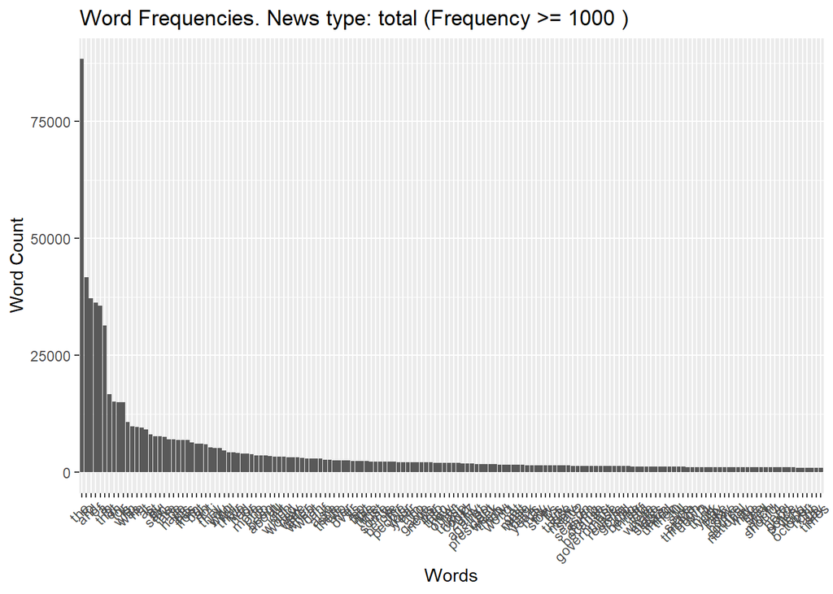

```r
plot_frequency <- function(data_set_name, min_frequency) {
  if (data_set_name == "credible") {
    filtered_words <- credible_news_frequencies[credible_news_frequencies$n >= min_frequency, ]
  } else if (data_set_name == "fake") {
    filtered_words <- fake_news_frequencies[fake_news_frequencies$n >= min_frequency, ]
  } else if (data_set_name == "total") {
    filtered_words <- data_total_frequencies[data_total_frequencies$n >= min_frequency, ]
  } else {
    stop("'data_set_name' should equal 'credible', 'fake' or 'total'")
  }

  p <- ggplot(filtered_words, aes(x = reorder(Word, -n), y = n)) +
    geom_bar(stat = "identity") +
    labs(x = "Words", y = "Word Count") +
    ggtitle(sprintf(
      "Word Frequencies. News type: %s (Frequency >= %s )",
      data_set_name,
      min_frequency)) + theme(axis.text.x = element_text(angle = 45, hjust = 1))

  plot(p)

  ggsave(sprintf(
    "%s_word_frequencies_%s.pdf",
    data_set_name,
    min_frequency), p)
}

# plotting frequencies with minimum threshold 1000, 500, 250, 100
# P.S.
# feel free to change
plot_frequency("total", 1000)
```

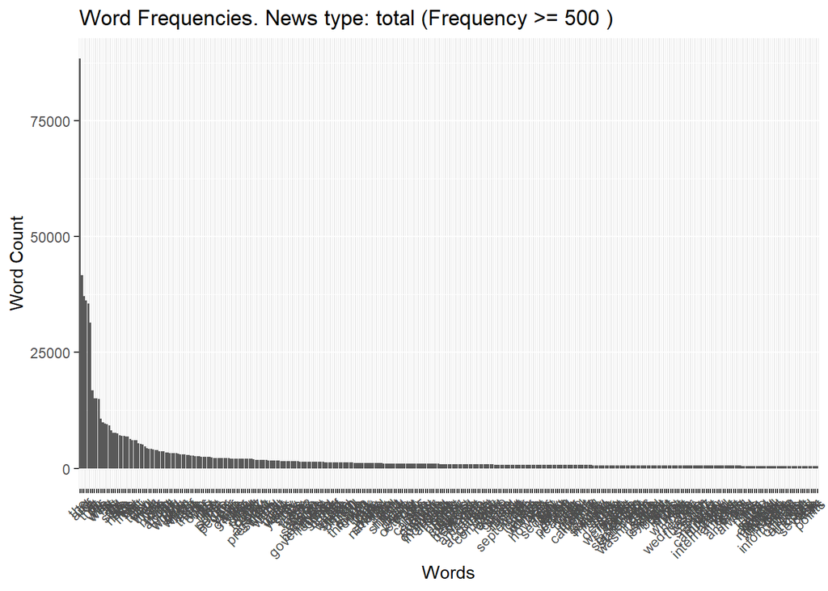

```r
plot_frequency("total", 500)
```

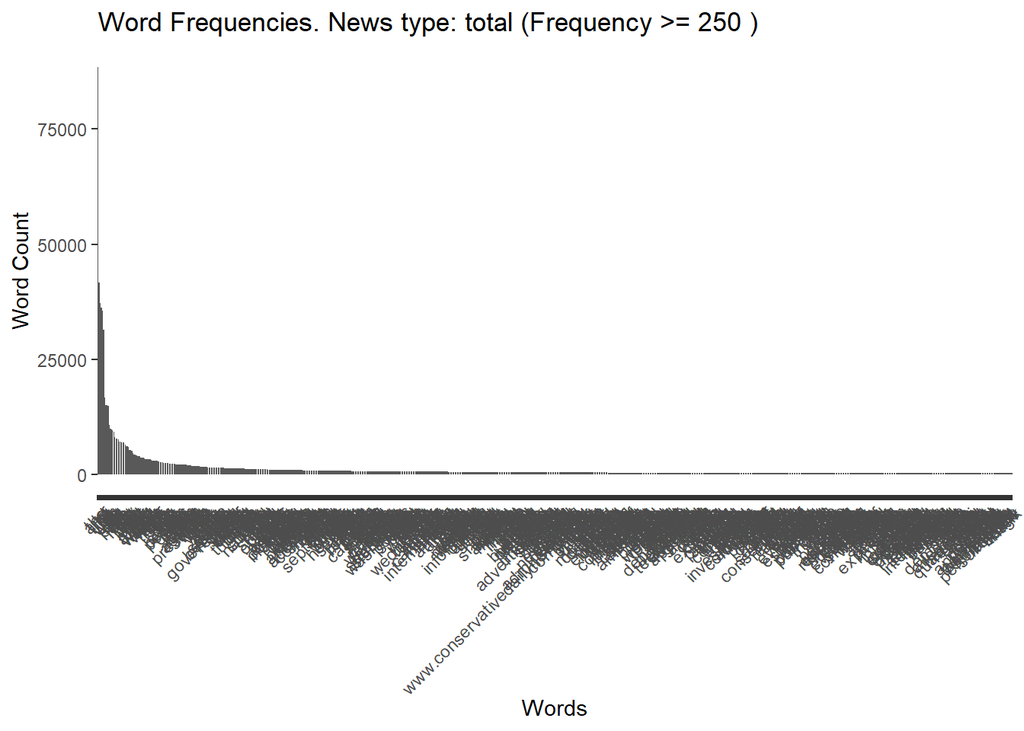

```r
plot_frequency("total", 250)
```

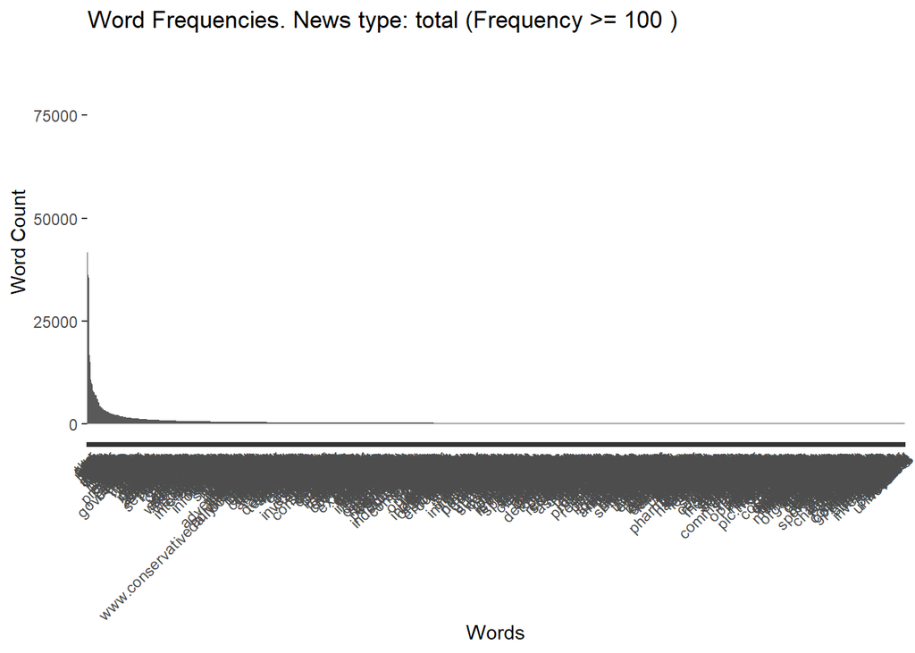

```r
plot_frequency("total", 100)
```

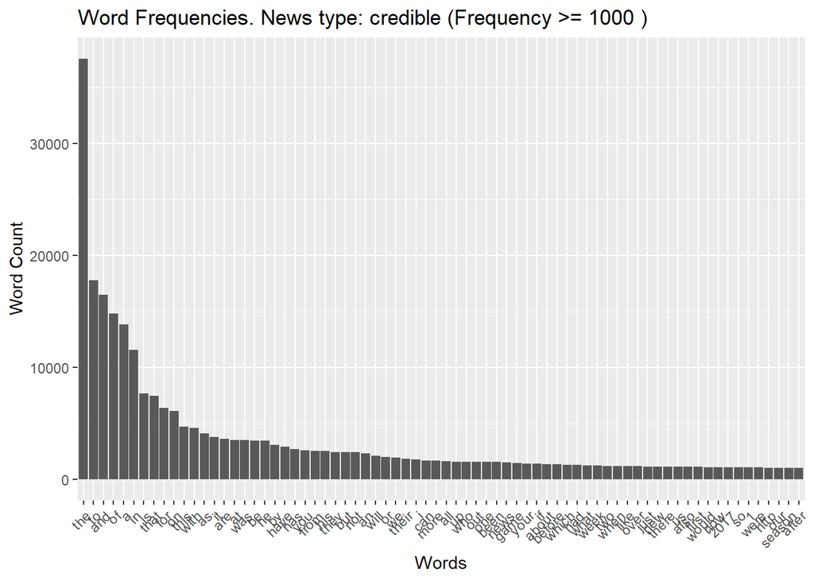

```r
# plotting frequencies for fake/credible with minimum threshold
# 1000, 500, 250, 100
# P.S.
# feel free to change
plot_frequency("credible", 1000)
```

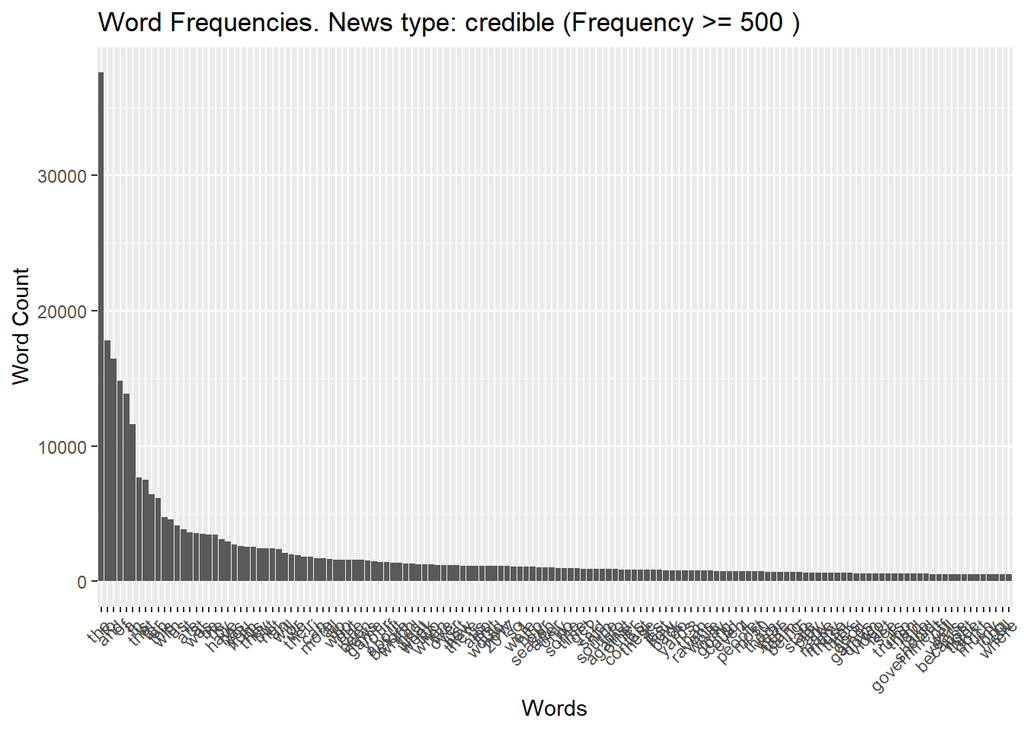

```r
plot_frequency("credible", 500)
```

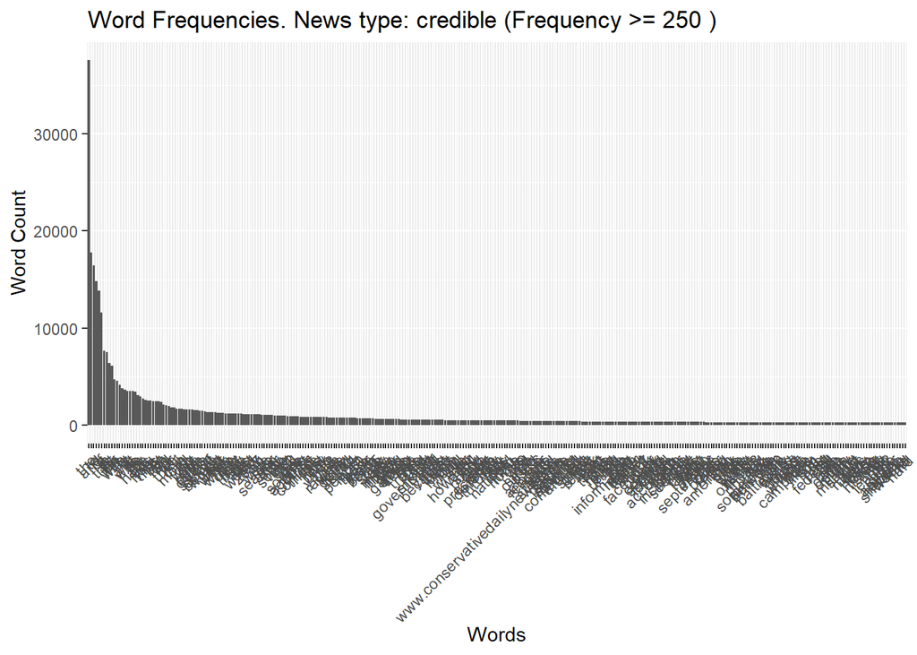

```r
plot_frequency("credible", 250)
```

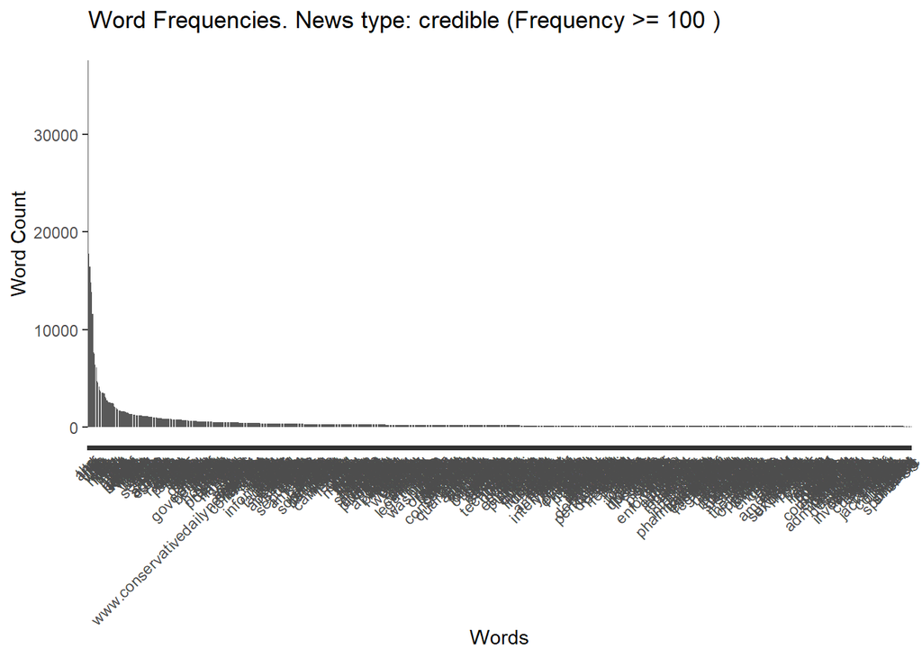

```r
plot_frequency("credible", 100)
```

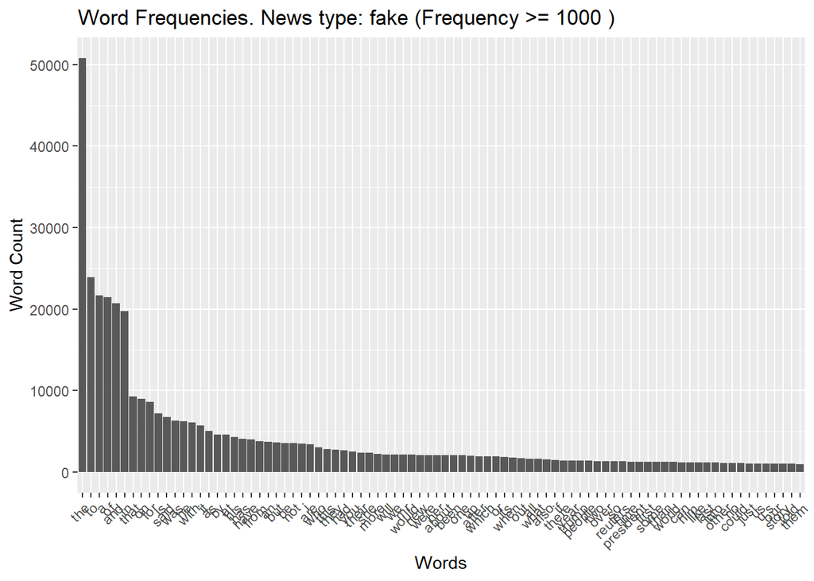

```r
plot_frequency("fake", 1000)
```

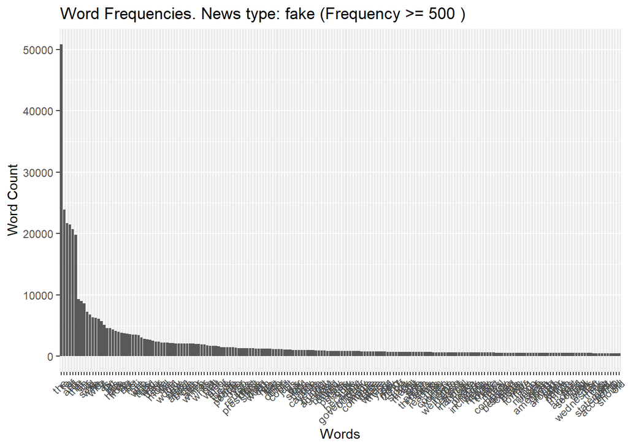

```r
plot_frequency("fake", 500)
```

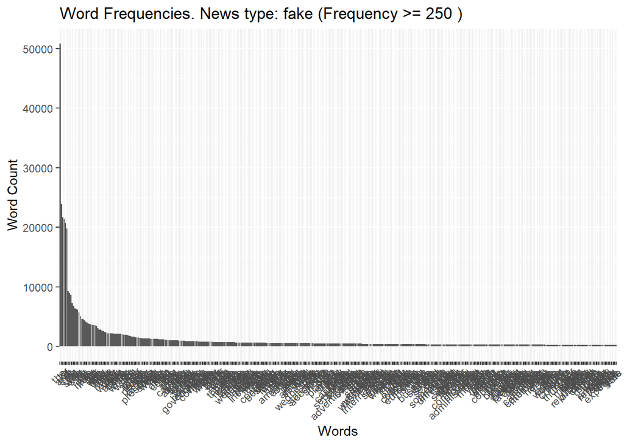

```r
plot_frequency("fake", 250)
```

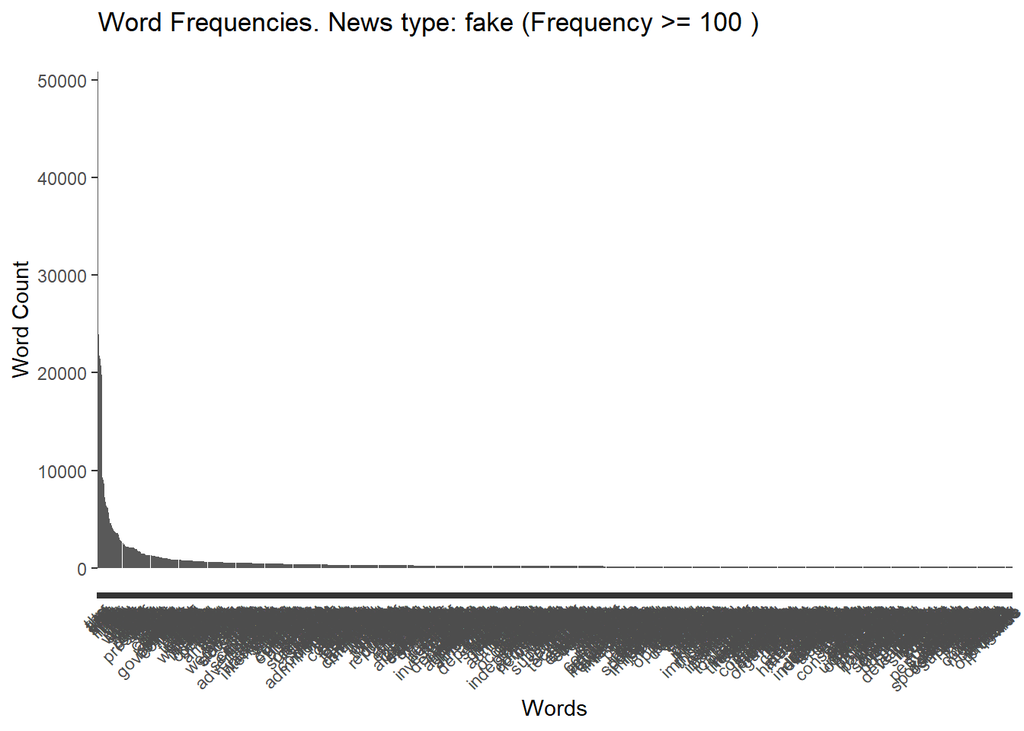

```r
plot_frequency("fake", 100)
```

## Classifier implementation

```r
credible_words <- credible_news_frequencies
fake_words <- fake_news_frequencies


all_unique_words <- nrow(data_total_frequencies)


prediction_of_message <- function(newmessage, data_current, unique_quantity)
  {

      current_words <- sum(data_current$n)

      words <- c()
      numbers <- c()

      message <- unlist(strsplit(newmessage, split = " "))
      for (x in message) {
        words <- c(words, x)
        if (!(x %in% data_current$Word)) {
          numbers <- c(numbers, 0)
        } else {
          idx <- which(data_current$Word==x)
          numbers <- c(numbers, data_current$n[idx[1]])
        }
      }
      need_data <- data.frame(Words = words, n = numbers)

      #Calculating probability that message is credible/fake (depends on request)
      res <- 1
      for (x in message){
        idx <- which(need_data$Word==x)
        prob <- ((need_data$n[idx[1]] + 1)/ (current_words + unique_quantity))
        res <- res * prob
      }

          return(res)
    }


check_message <- function(message, all_unique_words, credible_words, fake_words)
  {
      # Determines whether message is credible or fake
      prob_credible <- prediction_of_message(message, credible_words, all_unique_words)
      prob_fake <- prediction_of_message(message, fake_words, all_unique_words)

      label <- "fake"
      if (prob_credible > prob_fake){
        label <- "credible"
      }
      return(label)
    }


result <- c()
for (message in data_test_body){
  label <- check_message(message, all_unique_words, credible_words, fake_words)
  result <- c(result, label)
}

View(result)
expected <- data_test$Label

final_result <- data.frame(result, expected)
names(final_result) <- c("Result", "Expected")
```

## Measure effectiveness of your classifier

- Note that accuracy is not always a good metric for your classifier. Look at precision and recall curves, F1 score metric.
- Visualize them.
- Show failure cases.

```r
general_percentage <- final_result %>%
  mutate(Result = factor(Result)) %>%
  count(Result, Expected, .drop = FALSE, name = "Percentage") %>%
  mutate(Percentage = Percentage/sum(Percentage) * 100)

print(general_percentage)
```

```
##     Result Expected Percentage
## 1 credible credible 21.4463840
## 2 credible     fake  0.4987531
## 3     fake credible 33.9152120
## 4     fake     fake 44.1396509
```

```r
f1_percentage <- final_result %>%
  mutate(Result = factor(Result)) %>%
  count(Result, Expected, .drop = FALSE, name = "Percentage") %>%
  group_by(Result) %>%
  mutate(Percentage = Percentage/sum(Percentage) * 100)

print(f1_percentage)
```

```
## # A tibble: 4 × 3
## # Groups:   Result [2]
##   Result   Expected Percentage
##   <fct>    <chr>         <dbl>
## 1 credible credible      97.7
## 2 credible fake           2.27
## 3 fake     credible      43.5
## 4 fake     fake          56.5
```

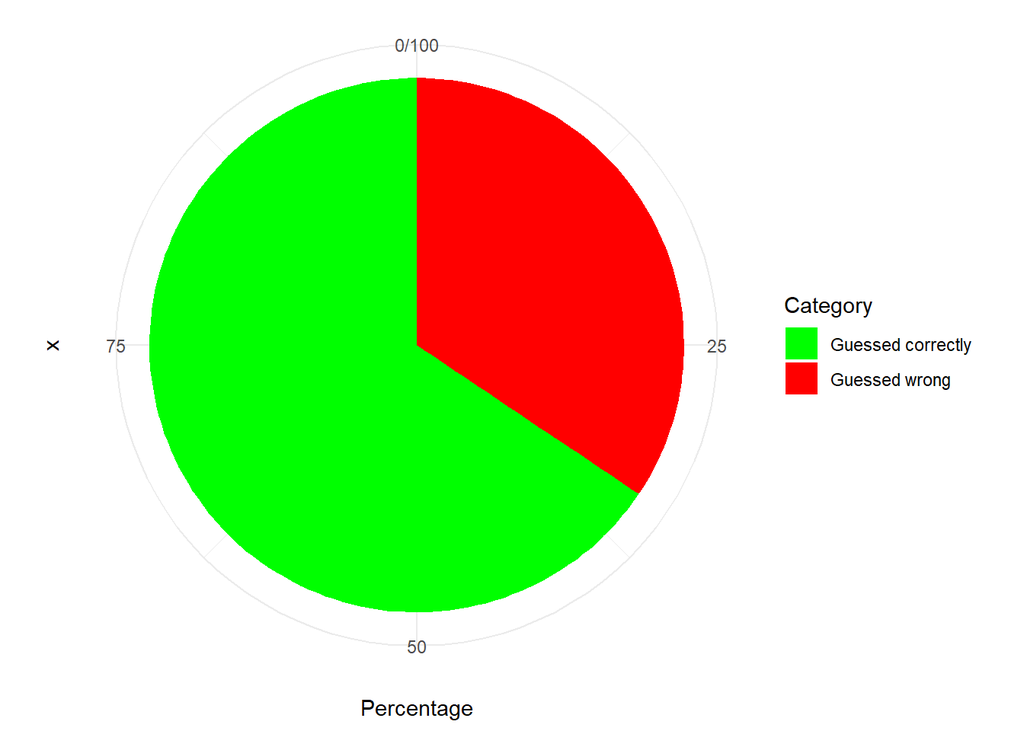

```r
final_result$code = ifelse(final_result$Result == final_result$Expected, 1, 0)

percentage_0 <- mean(final_result$code == 0) * 100
percentage_1 <- mean(final_result$code == 1) * 100

pie_data <- data.frame(
  Category = c("Guessed wrong", "Guessed correctly"),
  Percentage = c(percentage_0, percentage_1)
)

ggplot(pie_data, aes(x = " ", y = Percentage, fill = Category)) +
  geom_bar(stat = "identity", width = 1) +
  coord_polar(theta = "y") +
  scale_fill_manual(values = c("green", "red")) +
  theme_minimal()
```

```r
# F1 score
actual <- factor(rep(c(0, 1), times=c(table(final_result$Expected=="fake")[[1]],
                                      table(final_result$Expected=="fake")[[2]])))

pt <- sum(final_result$Result == "credible" & final_result$Expected == "credible")
pf <- sum(final_result$Result == "credible" & final_result$Expected == "fake")
nt <- sum(final_result$Result == "fake" & final_result$Expected == "fake")
nf <- sum(final_result$Result == "fake" & final_result$Expected == "credible")

pred <- factor(rep(c(0, 1, 0, 1), times=c(pt, pf, nt, nf)))

confusionMatrix(pred, actual, mode = "everything", positive="1")
```

[output not shown]

[figure not shown]

```r
confusion <- confusionMatrix(pred, actual, mode = "everything", positive = "1")

# Extract confusion matrix values
confusion_data <- as.data.frame(confusion$table)
names(confusion_data) <- c("Actual", "Predicted", "n")

# Create a custom confusion matrix plot
ggplot(data = confusion_data, aes(x = Actual, y = Predicted)) +
  geom_tile(aes(fill = n), color = "white") +
  scale_fill_gradient(low = "white", high = "blue") +
  theme_minimal() +
  labs(x = "Actual", y = "Predicted") +
  theme(legend.position = "bottom") +
  geom_text(aes(label = n), vjust = 1)
```

## Conclusions

Shakespeare would have said: “Shame on thee, thou who neglect the chances!”

As we have just discovered, despite claiming that probability in real life is pretty useless, actually there are fields that make knowledge of P&S bloom in its various colours. One can believe that the understanding of probability will never come in handy, yet its showtime begins unexpectedly.

However, it’s possible that the word might never occur in a category, which will lead to probability nullification. To avoid this, we use Laplace smoothing: we add 1 to numerator, and number of unique words in whole data set to the denominator. Only after smoothing we may proceed calculating probabilities.